# FINAL PROJECT:

## 6. Apply Logistic Regression.

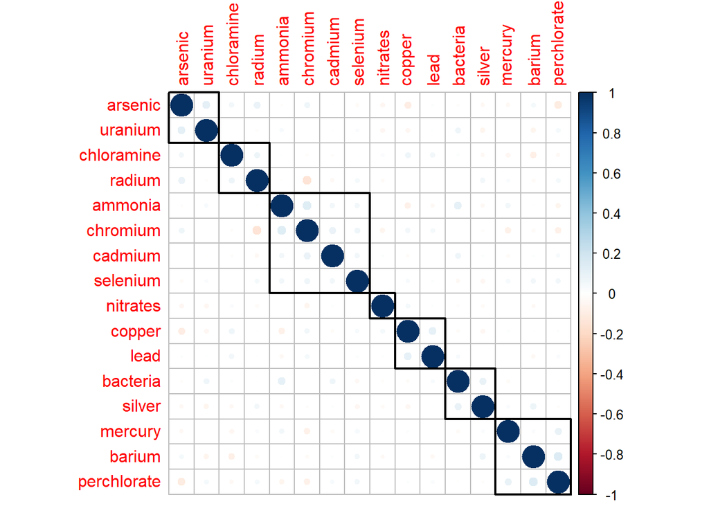

```r
New_Data <- data_frame[, -which(names(data_frame) ==  "viruses")]
New_Data_numeric_Data <- New_Data[, sapply(New_Data, is.numeric)]
New_numeric_scaled_data <- scale(New_Data_numeric_Data)
New_correlation_matrix <- cor(New_numeric_scaled_data)
corrplot(New_correlation_matrix, order = 'hclust', addrect = 7)
```

```r
# a. Use appropriate functions and arguments,
set.seed(123)
New_Data$is_safe <- factor(New_Data$is_safe,levels = c("no","yes"),labels = c(0,1))
# Check for NA values after factor conversion
missing_values <- sum(is.na(New_Data$is_safe))
train_index <- createDataPartition(New_Data$is_safe, p = 0.8, list = FALSE)
training_set <- New_Data[train_index, ]
testing_set <- New_Data[-train_index, ]
logistic_model <- glm(is_safe ~ . , family=binomial, training_set)
summary(logistic_model)
```

```
##
## Call:
## glm(formula = is_safe ~ ., family = binomial, data = training_set)
##
## Coefficients:
##               Estimate Std. Error z value Pr(>|z|)
## (Intercept)   5.293512   0.913091   5.797 6.74e-09 ***
## ammonia      -0.100609   0.015726  -6.398 1.58e-10 ***
## arsenic      -3.298078   8.085286  -0.408  0.68334
## barium       -0.072777   0.106404  -0.684  0.49400
## cadmium      47.572902  49.240650   0.966  0.33398
## chloramine   -0.027167   0.053314  -0.510  0.61036
## chromium      0.373776   0.488337   0.765  0.44403
## copper       -0.162372   0.208741  -0.778  0.43665
## bacteria     -0.127237   0.439983  -0.289  0.77244
## lead         -0.030981   2.253053  -0.014  0.98903
## nitrates     -0.072909   0.022728  -3.208  0.00134 **
## mercury     -18.378194  41.222198  -0.446  0.65572
## perchlorate  -0.075520   0.008872  -8.512  < 2e-16 ***
## radium       -0.063254   0.054002  -1.171  0.24146
## selenium     -1.275103   4.179657  -0.305  0.76031
## silver       -0.348210   0.843236  -0.413  0.67965
## uranium      -4.042110   4.435544  -0.911  0.36214
## ---
## Signif. codes:  0 '***' 0.001 '**' 0.01 '*' 0.05 '.' 0.1 ' ' 1
##
## (Dispersion parameter for binomial family taken to be 1)
##
##     Null deviance: 575.31  on 414  degrees of freedom
## Residual deviance: 420.37  on 398  degrees of freedom
## AIC: 454.37
##
## Number of Fisher Scoring iterations: 4
```

```r
test_predictions <- predict(logistic_model, newdata = testing_set, type = "response")
threshold <- 0.5
predicted_classes <- ifelse(test_predictions > threshold, 1, 0)
confusionMatrix(data = factor(predicted_classes), reference = testing_set$is_safe, positive = "1")
```

```
## Confusion Matrix and Statistics
##
##           Reference
## Prediction  0  1
##          0 42 13
##          1 10 38
##
##                Accuracy : 0.7767
##                  95% CI : (0.684, 0.8529)
##     No Information Rate : 0.5049
##     P-Value [Acc > NIR] : 1.275e-08
##
##                   Kappa : 0.5531
##
##  Mcnemar's Test P-Value : 0.6767
##
##             Sensitivity : 0.7451
##             Specificity : 0.8077
##          Pos Pred Value : 0.7917
##          Neg Pred Value : 0.7636
##              Prevalence : 0.4951
##          Detection Rate : 0.3689
##    Detection Prevalence : 0.4660
##       Balanced Accuracy : 0.7764
##
##        'Positive' Class : 1
##
```

```r
accuracy_confusionMatrix <- confusionMatrix(data = factor(predicted_classes), reference = testing_set$is_safe, positive = "1")
```

### b. Use visualization techniques for Regression, describe the result!

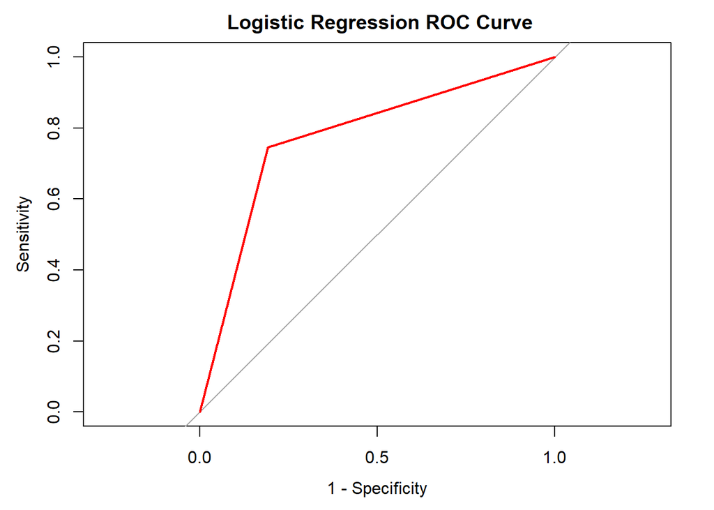

```r
roc_curve <- roc(testing_set$is_safe, predicted_classes)
plot(roc_curve, col = "red", main = " Logistic Regression ROC Curve", legacy.axes = TRUE)
```

```r
print(auc(roc_curve))
```

```
## Area under the curve: 0.7764
```

## 7.1 Algorithm Application

### Apply k-means clustering with k=3

### a. Use appropriate functions and arguments,

```r
kmean_clustering <- kmeans(New_numeric_scaled_data, centers = 3, nstart = 10)
# Assign cluster labels to observations
cluster_labels <- kmean_clustering$cluster
```

### b. Use visualization techniques. Describe the result!

### Visualize the clustering result

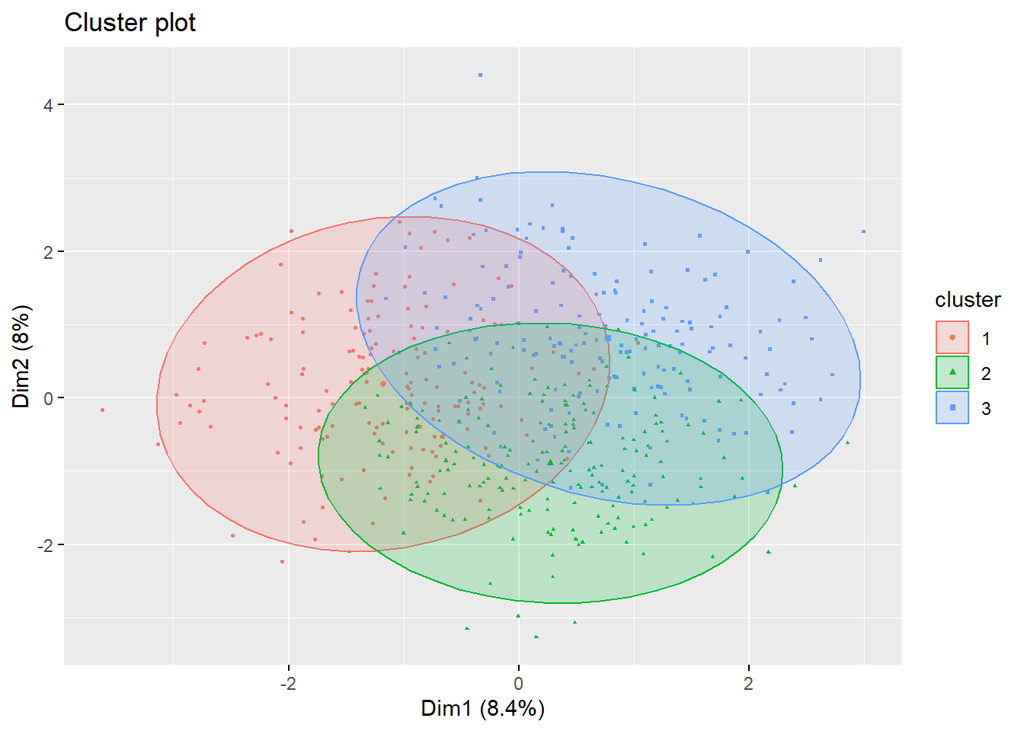

```r
fviz_cluster(kmean_clustering, New_numeric_scaled_data, ellipse.type = "norm",geom = "point",pointsize = 0.5)
```

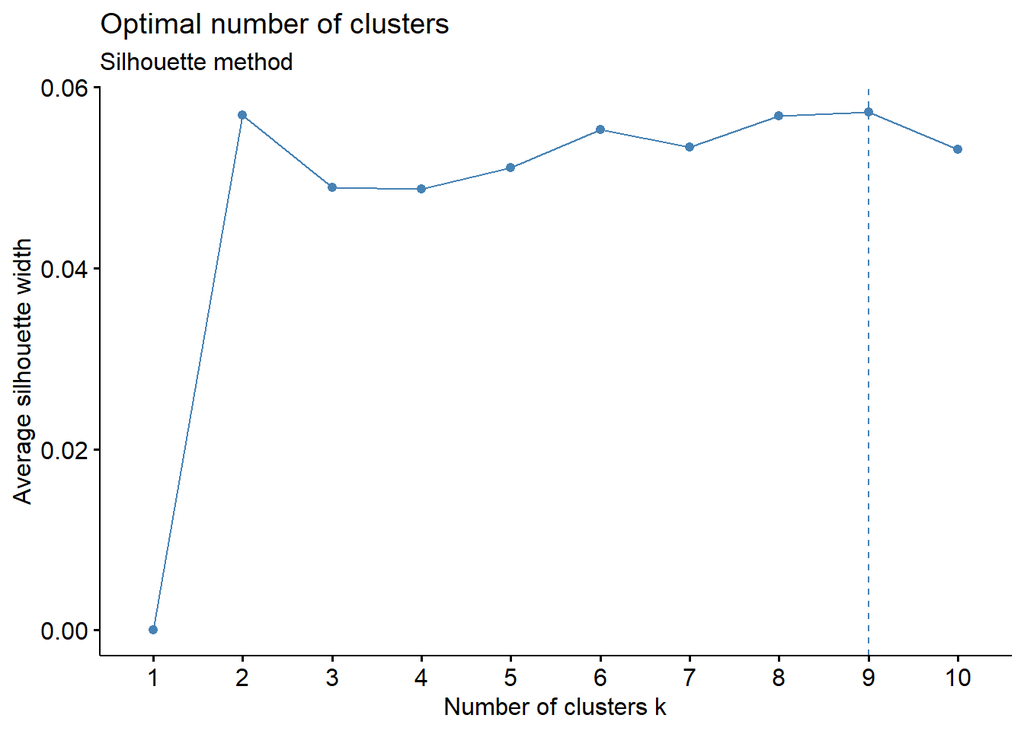

```r
fviz_nbclust(New_numeric_scaled_data, kmeans, method = "silhouette") +
  labs(subtitle = "Silhouette method")
```

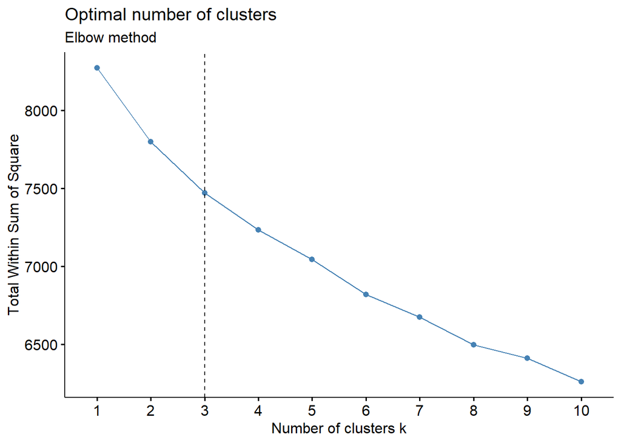

```r
fviz_nbclust(New_numeric_scaled_data, kmeans, method = "wss") +
  geom_vline(xintercept = 3, linetype = 2) +
  labs(subtitle = "Elbow method")
```

## 7.2 Algorithm Application

### a. Use appropriate functions and arguments

### Apply hierarchical clustering using complete linkage

```r
hierarchical_clustering <- hclust(dist(New_numeric_scaled_data), method = "complete")
```

### b. Use visualization techniques. Describe the result!

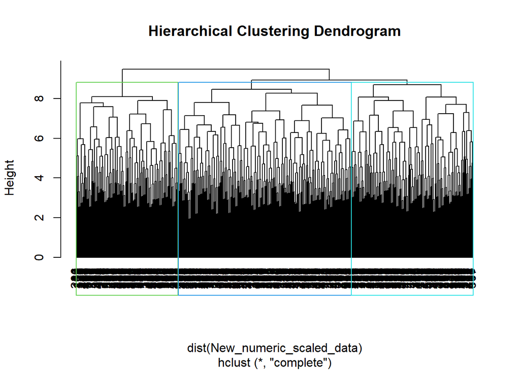

```r
cut_dendrogram <- cutree(hierarchical_clustering, k = 5)
# Visualize the clustering result
plot(hierarchical_clustering, hang = -1, main = "Hierarchical Clustering Dendrogram")
rect.hclust(hierarchical_clustering, k = 3, border = 3:6)
```

```r
print(cut_dendrogram)
```

```
##   [1] 1 2 1 1 3 3 4 1 2 4 5 4 3 5 1 3 4 3 3 3 5 3 5 4 1 3 4 5 2 5 5 5 2 2 3 1 2
##  [38] 5 4 1 2 5 3 5 3 2 3 2 4 2 2 4 1 5 1 1 1 3 5 5 3 1 1 2 1 4 2 2 3 1 1 5 1 1
##  [75] 5 5 5 2 2 1 2 2 4 1 1 1 3 5 5 3 5 4 5 3 3 5 5 1 5 4 1 5 1 5 1 1 4 3 1 1 2
## [112] 3 3 1 4 4 1 5 2 3 3 3 4 4 1 1 5 1 5 5 2 5 1 5 3 4 5 5 1 4 5 5 1 5 3 3 3 2
## [149] 1 1 1 2 5 5 3 5 2 5 1 1 4 1 4 5 3 5 3 1 2 4 5 1 1 3 3 5 4 4 3 4 2 5 2 1 5
## [186] 2 1 1 5 5 5 4 2 1 1 5 5 4 5 2 1 3 3 3 5 1 2 1 5 2 5 2 1 5 5 4 4 5 3 1 5 5
## [223] 1 1 3 1 1 5 2 1 5 4 4 1 1 1 5 1 5 3 5 5 5 1 2 1 2 2 3 2 4 2 2 4 5 1 5 3 5
## [260] 5 1 5 4 2 4 1 1 3 5 3 3 5 1 1 4 5 5 4 3 5 3 3 1 5 2 1 5 2 3 5 5 1 1 4 3 1
## [297] 5 3 1 3 1 5 5 5 2 1 2 2 2 4 5 1 4 4 4 1 5 3 1 3 1 3 5 2 1 3 5 1 3 4 3 1 1
## [334] 5 2 1 3 1 3 1 5 3 1 5 1 1 2 2 5 5 3 1 4 1 5 5 5 2 5 1 2 2 2 4 3 3 2 2 3 2
## [371] 1 4 2 5 3 1 3 2 5 1 1 2 3 5 3 3 2 5 3 5 1 2 5 5 1 5 2 1 2 1 5 5 1 1 5 3 5
## [408] 5 4 2 2 1 4 2 3 4 5 1 2 2 4 1 5 5 3 1 3 5 3 1 2 2 4 5 1 1 2 3 2 5 4 1 1 3
## [445] 4 3 4 3 5 5 4 2 5 4 4 3 1 3 2 2 5 4 4 1 5 4 2 2 5 5 1 3 5 5 5 5 1 3 5 2 5
## [482] 3 1 5 1 1 5 4 5 3 1 1 3 2 5 1 1 2 2 4 5 1 4 5 4 4 4 2 1 2 5 3 5 1 5 4 3 1
```

```r
print(cluster_labels)
```

```
##   [1] 2 2 3 1 3 2 1 3 3 1 1 2 2 2 2 1 3 3 2 2 1 3 1 2 1 3 1 1 3 2 3 2 2 3 3 3 2
##  [38] 2 3 2 2 2 3 3 3 3 2 2 2 1 2 3 1 3 3 3 2 3 2 1 2 1 3 3 1 2 3 3 2 1 1 1 2 2
##  [75] 2 1 1 1 2 1 2 3 2 1 3 2 3 1 2 2 2 2 1 2 1 2 2 1 1 3 3 2 3 2 3 3 1 3 2 3 2
## [112] 2 3 2 2 3 1 1 1 1 3 2 3 2 2 3 3 3 2 1 1 2 2 1 1 2 2 2 1 3 1 1 1 1 3 1 2 3
## [149] 1 1 1 2 2 2 3 2 3 3 1 2 3 3 2 1 3 1 1 2 2 2 1 1 3 3 2 1 2 2 3 2 2 2 1 2 2
## [186] 2 1 1 1 2 2 2 3 2 2 1 3 2 1 2 3 1 3 3 1 3 2 3 2 3 2 3 1 1 1 2 3 1 3 1 1 3
## [223] 1 1 2 3 1 1 3 3 1 3 3 3 1 3 1 1 2 3 2 1 1 3 3 1 2 3 3 3 2 3 3 3 3 3 1 2 1
## [260] 1 3 1 3 3 3 2 3 2 3 1 2 2 3 3 3 2 1 3 2 3 3 3 3 2 2 3 1 2 2 2 1 1 1 1 1 1
## [297] 1 1 1 3 2 1 3 1 2 1 2 2 3 3 2 2 2 3 3 1 1 3 3 2 3 1 2 2 1 1 1 1 3 3 3 3 3
## [334] 2 2 2 2 2 1 3 2 2 2 2 3 2 2 2 1 2 3 3 2 3 1 2 1 2 1 2 3 2 2 1 1 1 2 3 1 3
## [371] 3 2 3 3 3 1 1 3 1 2 1 2 3 3 3 1 2 3 1 1 2 3 2 2 2 1 2 2 2 3 3 3 3 3 2 3 1
## [408] 1 2 1 2 3 2 3 3 3 1 3 3 2 2 2 2 1 1 1 3 2 2 3 2 3 1 1 3 1 2 1 2 1 3 3 3 2
## [445] 2 1 2 3 3 2 2 2 2 3 1 1 1 1 2 3 2 2 2 1 2 2 3 3 1 1 2 1 1 3 3 1 2 1 2 2 2
## [482] 1 3 2 3 1 2 2 3 1 2 2 2 3 2 3 3 3 2 2 2 3 2 1 2 1 1 3 1 1 1 1 1 2 3 3 1 2
```

### c. Make your final comments clearly.

A clusters produced by hierarchical clustering.From 0 to 8, indicating the distance or dissimilarity between clusters. There are numerous vertical lines representing individual data points the formation of clusters at different heights or levels of similarity/dissimilarity. A title at the top reads “Hierarchical Clustering Dendrogram.” Colored horizontal lines (green and blue) intersecting the dendrogram at specific heights, possibly indicating specific cluster cut-offs

### b. Compare the results you have found in 7.1 and 7.2. Which performance scores you

### chose? What is your final decision? Make your comments!

**Comparison:** **Number of Clusters:** here we noticed that K-Means: has 3 clusters where **Hierarchical:** has 5 clusters so we can say that hierarchical clustering suggesting more granularity. So prefer hierarchical clustering algorithms: it assigned different data points to similar clusters. K-Means: Requires specifying the number of clusters (k). **Hierarchical:** Does not require specifying the number of clusters in advance.

## 8 Apply at least 2 Classification Techniques (other than logistic regresiion)

### a. Describe the reason you choose those 2 techniques.

After trying some Classification Techniques i see that those perform better on my data **Support Vector Machine (SVM) with Radial Kernel:** performs well in high-dimensional spaces, making it suitable for datasets with a large number of features. **Random Forest:** Random Forest can handle missing values without imputation.and provides a measure of variable importance.

## 8.1 Algorithm Application

### a.Use appropriate functions and arguments,

```r
suport_v_model <- train(is_safe ~ ., data = training_set, method = "svmRadial",
                        trControl = trainControl(method = "cv", number = 5))
test_predictions_svm <- predict(suport_v_model, newdata = testing_set)
confusionMatrix(test_predictions_svm, testing_set$is_safe)
```

```
## Confusion Matrix and Statistics
##
##           Reference
## Prediction  0  1
##          0 40 12
##          1 12 39
##
##                Accuracy : 0.767
##                  95% CI : (0.6734, 0.8446)
##     No Information Rate : 0.5049
##     P-Value [Acc > NIR] : 4.261e-08
##
##                   Kappa : 0.5339
##
##  Mcnemar's Test P-Value : 1
##
##             Sensitivity : 0.7692
##             Specificity : 0.7647
##          Pos Pred Value : 0.7692
##          Neg Pred Value : 0.7647
##              Prevalence : 0.5049
##          Detection Rate : 0.3883
##    Detection Prevalence : 0.5049
##       Balanced Accuracy : 0.7670
##
##        'Positive' Class : 0
##
```

### b. Use visualization techniques. Describe the result!

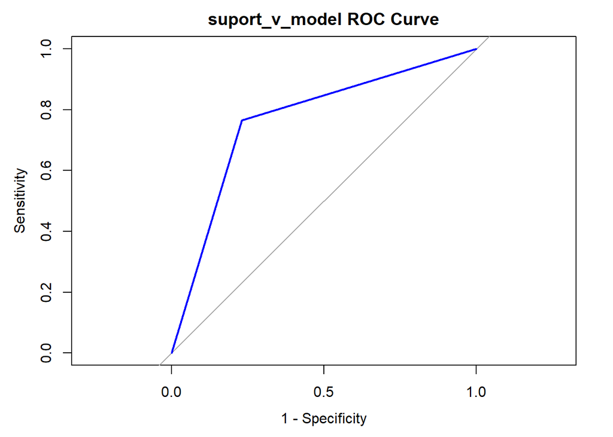

```r
roc_curve_svm <- roc(testing_set$is_safe, as.numeric(test_predictions_svm))
plot(roc_curve_svm, col = "blue", main = "suport_v_model ROC Curve", legacy.axes = TRUE)
```

```r
print(auc(roc_curve_svm))
```

```
## Area under the curve: 0.767
```

### c. Make your final comments clearly.

Suport_v_model ROC Curve” and shows the trade-off between sensitivity and specificity. The blue line represents the ROC curve, while the diagonal grey line represents random classification

## 8.2 Algorithm Application

### a. Use appropriate functions and arguments,

```r
random_forest_model <- train( is_safe ~ ., data = training_set, method = "rf", trControl = trainControl(method = "cv", number = 5))
test_predictions_rf <- predict(random_forest_model, newdata = testing_set)
# #Evaluate the Random Forest model
confusionMatrix(test_predictions_rf, testing_set$is_safe)
```

```
## Confusion Matrix and Statistics
##
##           Reference
## Prediction  0  1
##          0 34  6
##          1 18 45
##
##                Accuracy : 0.767
##                  95% CI : (0.6734, 0.8446)
##     No Information Rate : 0.5049
##     P-Value [Acc > NIR] : 4.261e-08
##
##                   Kappa : 0.535
##
##  Mcnemar's Test P-Value : 0.02474
##
##             Sensitivity : 0.6538
##             Specificity : 0.8824
##          Pos Pred Value : 0.8500
##          Neg Pred Value : 0.7143
##              Prevalence : 0.5049
##          Detection Rate : 0.3301
##    Detection Prevalence : 0.3883
##       Balanced Accuracy : 0.7681
##
##        'Positive' Class : 0
##
```

### b. Use visualization techniques. Describe the result!

Visualize results (ROC curve)

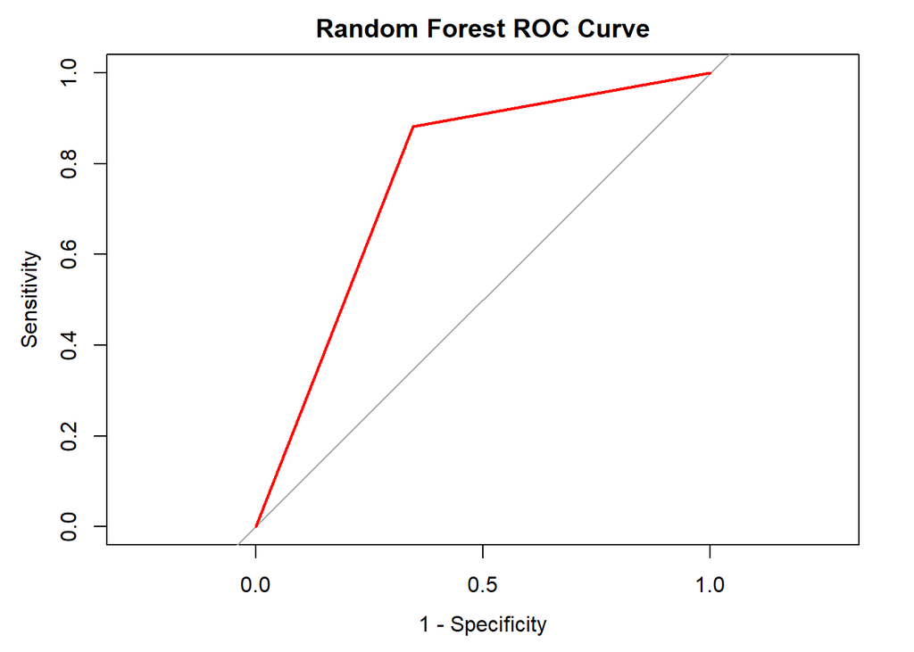

```r
roc_curve_rf <- roc(testing_set$is_safe, as.numeric(test_predictions_rf))
plot(roc_curve_rf, col = "red", main = "Random Forest ROC Curve", legacy.axes = TRUE)
```

```r
# Print the ROC curve
print(auc(roc_curve_rf))
```

```
## Area under the curve: 0.7681
```

## X: (7p) Use the PCA results (principal components) you have found in “step 5” ; either for logistic regression or any other classification techniques

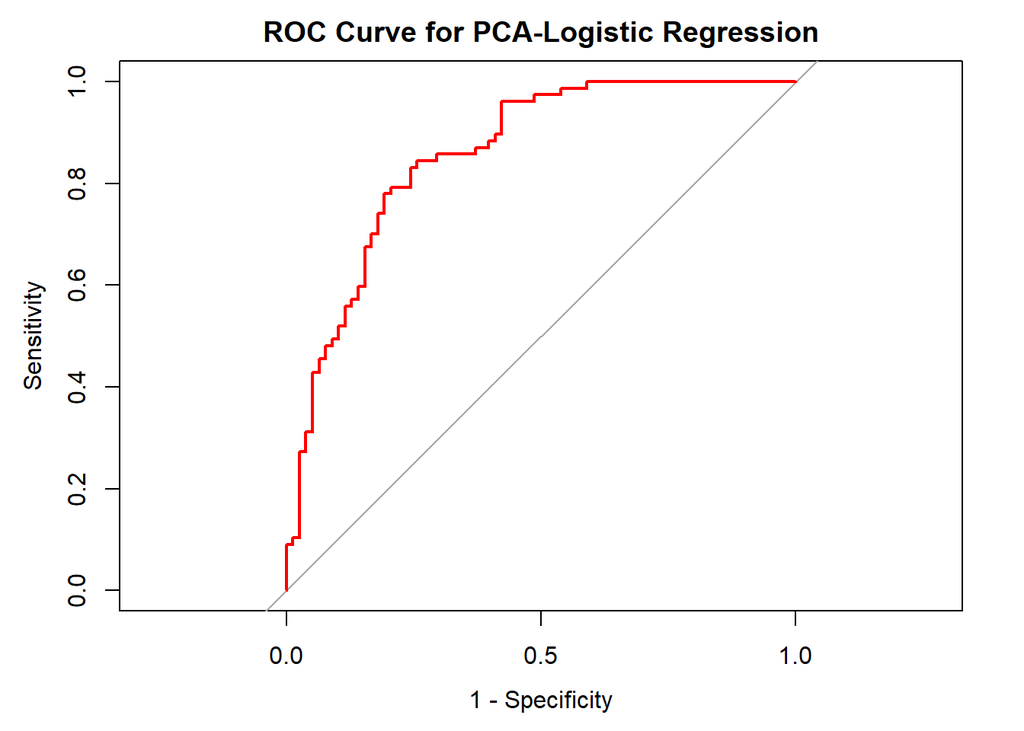

```r
num_components <- 3
selected_components <- pca_result$x [, 1:num_components]
data_frame_with_components <- cbind(New_Data, selected_components)

set.seed(123)
with_pca_train_indix <- createDataPartition(data_frame$is_safe, p = 0.7, list = FALSE)
with_pca_train_data <- data_frame_with_components[with_pca_train_indix, ]
with_pca_test_data <- data_frame_with_components[-with_pca_train_indix, ]
logistic_model_with_components <- glm(is_safe ~ ., data = with_pca_train_data, family = "binomial")
predictions_with_components <- predict(logistic_model_with_components, newdata = with_pca_test_data, type = "response")

# Evaluate the model with principal components
roc_curve_with_components <- roc(with_pca_test_data$is_safe, as.numeric(predictions_with_components))
plot(roc_curve_with_components, col = "red", main = "ROC Curve for PCA-Logistic Regression", legacy.axes = TRUE)
```

```r
cat("AUC with principal components: ", auc(roc_curve_with_components))
```

```
## AUC with principal components:  0.8568099
```

```r
cat("AUC with original data: ", auc(roc_curve))
```

```
## AUC with original data:  0.7763952
```

### Y: Missing Data imputation:

### a.Delete about 20%-40% of your data set randomly. Make them NA values, as if they are missing. Describe what you did there.

Set a random seed for reproducibility

```r
set.seed(123)
str(data_frame)
```

```
## 'data.frame':    518 obs. of  18 variables:
##  $ ammonia    : num  9.08 21.16 14.02 11.33 24.33 ...
##  $ arsenic    : num  0.04 0.01 0.04 0.04 0.03 0.03 0.01 0.04 0.01 0.02 ...
##  $ barium     : num  2.85 3.31 0.58 2.96 0.2 2.88 1.35 0.66 0.71 1.37 ...
##  $ cadmium    : num  0.007 0.002 0.008 0.001 0.006 0.003 0.004 0.001 0.005 0.007 ...
##  $ chloramine : num  0.35 5.28 4.24 7.23 2.67 0.8 1.28 6.22 3.14 6.4 ...
##  $ chromium   : num  0.83 0.68 0.53 0.03 0.69 0.43 0.62 0.1 0.77 0.49 ...
##  $ copper     : num  0.17 0.66 0.02 1.66 0.57 1.38 1.88 1.86 1.45 0.82 ...
##  $ bacteria   : num  0.2 0.65 0.05 0.71 0.13 0.67 0.13 0.16 0.35 0.83 ...
##  $ viruses    : num  0 0.65 0.003 0.71 0.001 0.67 0.007 0.005 0.002 0.83 ...
##  $ lead       : num  0.054 0.1 0.078 0.016 0.117 0.135 0.021 0.197 0.167 0.109 ...
##  $ nitrates   : num  16.08 2.01 14.16 1.41 6.74 ...
##  $ mercury    : num  0.007 0.003 0.006 0.004 0.003 0.006 0.007 0.001 0.004 0.01 ...
##  $ perchlorate: num  37.75 32.26 50.28 9.12 16.9 ...
##  $ radium     : num  6.78 3.21 7.07 1.72 2.41 5.42 2.84 7.24 4.99 0.08 ...
##  $ selenium   : num  0.08 0.08 0.07 0.02 0.02 0.08 0.1 0.08 0.08 0.03 ...
##  $ silver     : num  0.34 0.27 0.44 0.45 0.06 0.19 0.24 0.08 0.25 0.31 ...
##  $ uranium    : num  0.02 0.05 0.01 0.05 0.02 0.02 0.08 0.07 0.08 0.01 ...
##  $ is_safe    : Factor w/ 2 levels "no","yes": 2 2 1 2 2 2 1 1 2 2 ...
```

```r
deleted<-data_frame
deleted$is_safe <- factor(deleted$is_safe,levels = c("no","yes"),labels = c(0,1))
# Create a mask for missing values (20%-40% missing)
missing_mask <- matrix(sample(c(TRUE, FALSE), size = ncol(deleted) * nrow(deleted), prob = c(0.2, 0.8), replace = TRUE),
                       nrow = nrow(deleted))
# Set missing values in the dataset
deleted_data <- deleted
deleted_data[missing_mask] <- NA
```

### Describe what you did there.

Here we first Randomly deleted 20 and 40 % of the original data by automatically creating a “NA” for some columns